# Compito di Statistica

Scrivere in stampatello

| COGNOME | $\LARGE\square$ | $\LARGE\square$ | $\LARGE\square$ | $\LARGE\square$ | $\LARGE\square$ | $\LARGE\square$ | $\LARGE\square$ | $\LARGE\square$ | $\LARGE\square$ | $\LARGE\square$ | $\LARGE\square$ | $\LARGE\square$ | $\LARGE\square$ | $\LARGE\square$ | $\LARGE\square$ | $\LARGE\square$ | $\LARGE\square$ | $\LARGE\square$ | $\LARGE\square$ | $\LARGE\square$ |
| --- | --- | --- | --- | --- | --- | --- | --- | --- | --- | --- | --- | --- | --- | --- | --- | --- | --- | --- | --- | --- |
| NOME | $\LARGE\square$ | $\LARGE\square$ | $\LARGE\square$ | $\LARGE\square$ | $\LARGE\square$ | $\LARGE\square$ | $\LARGE\square$ | $\LARGE\square$ | $\LARGE\square$ | $\LARGE\square$ | $\LARGE\square$ | $\LARGE\square$ | $\LARGE\square$ | $\LARGE\square$ | $\LARGE\square$ | $\LARGE\square$ | $\LARGE\square$ | $\LARGE\square$ | $\LARGE\square$ | $\LARGE\square$ |
| Matricola | $\LARGE\square$ | $\LARGE\square$ | $\LARGE\square$ | $\LARGE\square$ | $\LARGE\square$ | $\LARGE\square$ | $\LARGE\square$ | $\LARGE\square$ | $\LARGE\square$ | $\LARGE\square$ | $\LARGE\square$ | $\LARGE\square$ | $\LARGE\square$ | $\LARGE\square$ | $\LARGE\square$ | $\LARGE\square$ | $\LARGE\square$ | $\LARGE\square$ | $\LARGE\square$ | $\LARGE\square$ |
| CDL | $\LARGE\square$ | $\LARGE\square$ | $\LARGE\square$ | $\LARGE\square$ | $\LARGE\square$ |  |  |  |  |  |  |  |  |  |  |  |  |  |  |  |

### Esercizio 1

| $[\text{x}_j,$ | $\text{x}_{j+1})$ | $n_j$ |
| --- | --- | --- |
| -10 | -5 | 43 |
| -5 | 0 | 86 |
| 0 | 1 | 43 |
| 1 | 5 | 9 |
|  |  | 181 |

1.a (**Punti 14 su 104 (4.04 su 30)**) Individuare la classe modale

| $[\text{x}_j,$ | $\text{x}_{j+1})$ | $n_j$ | $f_j$ | $b_j$ | $h_j$ | $F_j$ |
| --- | --- | --- | --- | --- | --- | --- |
| -10 | -5 | 43 | 0.2376 | 5 | 4.751 | 0.2376 |
| -5 | 0 | 86 | 0.4751 | 5 | 9.503 | 0.7127 |
| 0 | 1 | 43 | 0.2376 | 1 | 23.757 | 0.9503 |
| 1 | 5 | 9 | 0.0497 | 4 | 1.243 | 1.0000 |
|  |  | 181 | 1.0000 | 15 |  |  |

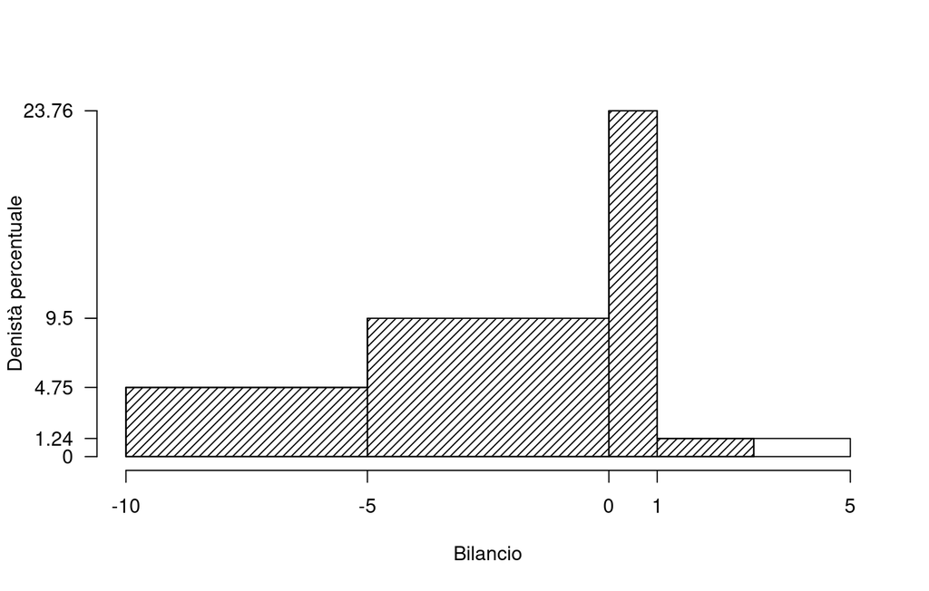

1.b (**Punti 3 su 104 (0.87 su 30)**) Qual è la percentuale di imprese con bilancio inferiore a 3 (centomila) euro?

1.c (**Punti 2 su 104 (0.58 su 30)**) la media aritmetica è pari a -2.6376, in base al punto 1a che relazione dobbiamo attenderci tra media, mediana e moda?

1.d (**Punti 2 su 104 (0.58 su 30)**) Si considerino i seguenti dati

$$\{x_1=1.2,x_2=2.3,x_3=6.7\}$$

Per quale valore di $x$
$$f(x)=(x_1-x)^2+(x_2-x)^2+(x_3-x)^2$$
$f$ è minima?

### Esercizio 2

Si consideri un’urna così formata,
$$\left\{\fbox{1},\fbox{2},\fbox{3},\fbox{4},\fbox{5},\fbox{6},\fbox{7},\fbox{8}\right\}.$$
Si vince se si estrae un numero maggiore o uguale a 6.

Si estrae *con* reintroduzione.

2.a (**Punti 14 su 104 (4.04 su 30)**) Qual è la probabilità di vincere almeno 5 volte su 6 estrazioni?

Sia $X$ la VC che conta il numero di di vittorie in 6 giocate, quindi $n=6$ replicazioni di una Bernoulli $X_i\sim\mbox{Ber}(\pi=3/8)$ e quindi

$$X=X_1+...+X_n\sim\mbox{Binom}(n=6,\pi=0.375)$$

2.b (**Punti 3 su 104 (0.87 su 30)**) Calcolare la probabilità di vincere la prima volta alla quarta estrazione.

Ogni singola giocata $X_i$ è una Bernoulli $X_i\sim\mbox{Ber}(\pi=3/8)$ e quindi
$$\begin{eqnarray*}
E&=&\text{Vincere la prima volta alla quarta estrazione}\\
&=& X_1=0~\cap~X_2=0~\cap~X_3=0~\cap~X_4=1\\
P(E)&=&P(X_1=0~\cap~X_2=0~\cap~X_3=0~\cap~X_4=1)\\
&=&P(X_1=0)P(X_2=0)P(X_3=0)P(X_4=1)\\
&=&\left(1-\frac 38\right)\left(1-\frac 38\right)\left(1-\frac
38\right)\frac 38\\
&=&\left(\frac 58\right)^3\frac 38\\
&=&0.0916
\end{eqnarray*}$$

2.c (**Punti 3 su 104 (0.87 su 30)**) Se $A$ e $B$ sono due eventi tali che, $P(A)>0$, $P(B)>0$, $P(A\cap B)=0$. $A$ e $B$ possono essere indipendenti?

No, in quanto, se $A$ e $B$ sono indipendenti
$$P(A\cap B)=P(A)P(B)\neq0$$

2.d (**Punti 2 su 104 (0.58 su 30)**) Sia $X\sim N(3.2,(1.1)^2)$ e sia $Y\sim\chi_{n-1}^2$, posto
$$T=\frac{\left(\frac{X-3.2}{1.1}\right)}{\sqrt{\frac{Y}{n-1}}},$$
come si distribuisce $T$?

Si noti che
$$Z=\left(\frac{X-3.2}{1.1}\right)\sim N(0,1)$$
e che
$$T=\frac{Z}{\sqrt{\frac{Y}{n-1}}}\sim t_{n-1}$$

### Esercizio 3

3.a (**Punti 14 su 104 (4.04 su 30)**) Un’urna contiene 4 palline numerate: $\fbox{0}$, $\fbox{1}$, $\fbox{4}$ e $\fbox{6}$. Si estrae 100 volte con reinserimento. Qual è la probabilità che la media delle 100 estrazioni sia maggiore di 2.8?

$$\begin{eqnarray*}
\mu &=& \frac 1{ 4 }( 0 + 1 + 4 + 6 )= 2.75 \\
\sigma^2 &=& \frac 1{ 4 }( 0 ^2+ 1 ^2+ 4 ^2+ 6 ^2 )-( 2.75 )^2=
5.688
\end{eqnarray*}$$
**Teorema del Limite Centrale (media VC qualunque)**

Siano $X_1$,…,$X_n$, $n=100$ VC IID, tc $E(X_i)=\mu=2.75$ e $V(X_i)=\sigma^2=5.688,\forall i$, posto:
$$\bar X=\frac{S_n}n =\frac{X_1 + ... + X_n}n$$
allora:
$$\begin{eqnarray*}
\bar X & \mathop{\sim}\limits_{a}& N(\mu,\sigma^2/n) \\
&\sim & N\left(2.75,\frac{5.688}{100}\right) \\
&\sim & N(2.75,0.05688)
\end{eqnarray*}$$

$$\begin{eqnarray*}
P(\bar X > 2.8)
&=& P\left( \frac {\bar X - \mu}{\sqrt{\sigma^2/n}} >
\frac {2.8 - 2.75}{\sqrt{0.0569}} \right) \\
&=& P\left( Z > 0.21\right) \\ &=&
1-P(Z< 0.21 )\\
&=& 1-\Phi( 0.21 ) \\ &=& 0.4168
\end{eqnarray*}$$

### Esercizio 4

4.a (**Punti 3 su 104 (0.87 su 30)**) Sono stati estratti $n=10$ valori da una Bernoulli di parametro $\pi$ incognito e si è ottenuti 4 successi in 10 estrazioni. Ricavare, $\widehat{SE(\hat\pi)}$ lo Standard Error stimato di $\hat\pi$ di massima verosimiglianza.

4.b (**Punti 3 su 104 (0.87 su 30)**) Sia $h$ uno stimatore per $\theta$. Cosa significa dire che $h$ è corretto asintoticamente?

4.c (**Punti 3 su 104 (0.87 su 30)**) Definire gli errori di primo e di secondo tipo e le relative probabilità.

4.d (**Punti 3 su 104 (0.87 su 30)**) Un dado viene lanciato 60 volte e si ottiene

| 1 | 2 | 3 | 4 | 5 | 6 |
| --- | --- | --- | --- | --- | --- |
| 3 | 4 | 18 | 16 | 7 | 12 |

Ci si chiede se il dado sia truccato. Posto a test
$$\begin{cases}
H_0:\pi_j=\frac 16, j = 1,...,6
\end{cases}$$
si ottiene un $p_{\text{value}}=0.0014$. Il dado si può ritenere truccato? Perché?

### Esercizio 5

(**Punti 14 su 104 (4.04 su 30)**) In uno studio sui consumi sono stati intervistati $n=25$ individui sui quali è stato rilevato il reddito mensile $X$ (in migliaia di euro), e il consumo $Y$ (in migliaia di euro). Il modello di regressione
$$Y_i=\beta_0+\beta_1 x_i+\varepsilon_i$$
ha fornito i seguenti risultati

$$\begin{align*}
\hat\beta_0&=0.60, &\hat\beta_1&=0.75, &r&=0.87\\
\bar x&=1.61 &\hat \sigma_X&=0.90\\
\bar y&=1.81 &\hat \sigma_Y&=0.78\\
\end{align*}$$

Testare al 5% l’ipotesi che il consumo di sussistenza $\beta_0$ sia uguale 0.5 contro l’alternativa che sia maggiore.

$$\begin{eqnarray*}
\hat{\sigma_\varepsilon}^2&=&(1-r^2)\hat\sigma_Y^2\\
&=& (1-0.7569)\times0.6084\\
&=& 0.1479\\
S_\varepsilon^2 &=& \frac{n} {n-2}
\hat{\sigma_\varepsilon}^2\\
&=& \frac{25} {25-2} \hat{\sigma_\varepsilon}^2 \\
&=& \frac{25} {25-2} \times 0.1479 = 0.1608
\end{eqnarray*}$$

E quindi

$$\begin{eqnarray*}
V(\hat\beta_{0}) &=& \sigma_{\varepsilon}^{2} \left( \frac{1}
{n} + \frac{\bar{x}^{2}} {n \hat{\sigma}^{2}_{X}} \right)\\
\widehat{V(\hat\beta_{0})} &=& S_{\varepsilon}^{2}\left(
\frac{1} {n} + \frac{\bar{x}^{2}} {n \hat{\sigma}^{2}_{X}} \right)\ \\
&=& 0.1608\times\left( \frac{1} {25} + \frac{1.61^{2}}
{25\times 0.81} \right)\\
\widehat{SE(\hat\beta_{0})} &=& \sqrt{0.027}\\
&=& 0.1643
\end{eqnarray*}$$

$\fbox{A}$ FORMULAZIONE DELLE IPOTESI
$$\begin{cases}
H_0:\beta_{0} = 0.5\\
H_1:\beta_{0} > 0.5
\end{cases}$$

$\fbox{B}$ SCELTA E CALCOLO STATISTICA-TEST, $T$ Test su un coefficiente di regressione: $\Rightarrow$ t-Test.

$$\begin{eqnarray*}
\frac{\hat\beta_{0} - \beta_{0;H_0}}
{\widehat{SE(\hat\beta_{0})}}&\sim&t_{n-2}\\
t_{\text{obs}}
&=& \frac{ (0.6- 0.5)} {0.1643}
= 0.6085\, .
\end{eqnarray*}$$

$\fbox{C}$ DECISIONE Dalle tavole si ha $t_{(25-2);\, 0.05} = 1.7109$.
$$t_{\text{obs}} = 0.6085 < t_{23;\, 0.05}
= 1.7109$$
CONCLUSIONE: i dati **sono** coerenti con $H_{0}$ al LdS del 5%

**Graficamente**

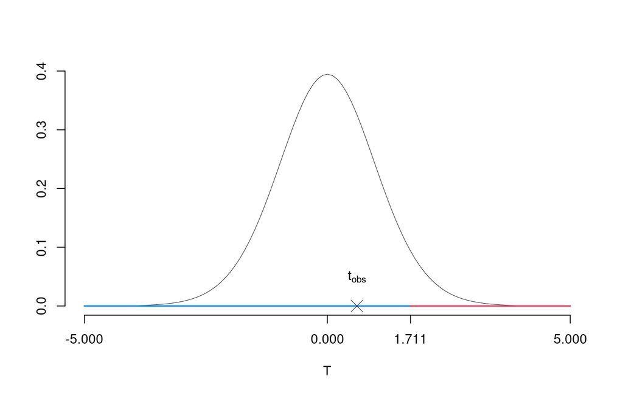

Il $p_{\text{value}}$ è
$$P(T_{n-2}>t_{\text{obs}})=P(T_{n-2}> 0.608
)= 0.2744$$

### Esercizio 6

6.a (**Punti 14 su 104 (4.04 su 30)**) Stimare il modello di regressione dove $Y$ viene spiegata da $X$

6.b (**Punti 3 su 104 (0.87 su 30)**) Qual è la percentuale di varianza spiegata dal modello?

$$\begin{eqnarray*}
r&=&\frac{\text{cov}(X,Y)}{\sigma_X\sigma_Y}=\frac{ 0.5711 }{
2.756 \times 0.2494 }= 0.8307 \\r^2&=& 0.6901 < 0.75
\end{eqnarray*}$$
Il modello **non** si adatta bene ai dati.

6.c (**Punti 2 su 104 (0.58 su 30)**) Se in un modello di regressione si conoscono $\hat\beta_1$, $r^2$ e $\hat\sigma_X$ è possibile ricavare $\hat\sigma_Y$? In che modo?

$$\begin{eqnarray*}
\hat\beta_1 &=& \frac{\text{cov}(x,y)}{\hat\sigma_X^2}\\
\text{cov}(x,y)&=&\hat\beta_1\hat\sigma_X^2\\
r&=&\frac{\text{cov}(x,y)}{\hat\sigma_X\hat\sigma_Y}\\
\hat\sigma_Y&=&\frac{\text{cov}(x,y)}{r\hat\sigma_X}\\
&=&\frac{\hat\beta_1\hat\sigma_X^2}{r\hat\sigma_X}\\
&=&\frac{\hat\beta_1}{r}\hat\sigma_X
\end{eqnarray*}$$

6.d (**Punti 2 su 104 (0.58 su 30)**) Cosa significa che il coefficiente di correlazione è invariante alle trasformazioni lineari?